# Diamonds Analysis

## by (Abdullah Elsayed)

##### Let's import all packages

```python
import numpy as np
import pandas as pd
import matplotlib.pyplot as plt
import seaborn as sb
```

```python
# load in the dataset into a pandas dataframe
diamonds = pd.read_csv('diamonds.csv')
```

## Dataset Overview

> let's just take a moment to get a high-level overview of the dataset. We can refer back to these points if we need to get our bearings on what we should expect to see from each variable.

```python
# high-level overview of data shape and composition
print(diamonds.shape)
print(diamonds.info())
diamonds.head(10)
```

```
(53940, 10)
<class 'pandas.core.frame.DataFrame'>
RangeIndex: 53940 entries, 0 to 53939
Data columns (total 10 columns):
 #   Column   Non-Null Count  Dtype
---  ------   --------------  -----
 0   carat    53940 non-null  float64
 1   cut      53940 non-null  object
 2   color    53940 non-null  object
 3   clarity  53940 non-null  object
 4   depth    53940 non-null  float64
 5   table    53940 non-null  float64
 6   price    53940 non-null  int64
 7   x        53940 non-null  float64
 8   y        53940 non-null  float64
 9   z        53940 non-null  float64
dtypes: float64(6), int64(1), object(3)
memory usage: 4.1+ MB
None
```

|  | carat | cut | color | clarity | depth | table | price | x | y | z |
| --- | --- | --- | --- | --- | --- | --- | --- | --- | --- | --- |
| 0 | 0.23 | Ideal | E | SI2 | 61.5 | 55.0 | 326 | 3.95 | 3.98 | 2.43 |
| 1 | 0.21 | Premium | E | SI1 | 59.8 | 61.0 | 326 | 3.89 | 3.84 | 2.31 |
| 2 | 0.23 | Good | E | VS1 | 56.9 | 65.0 | 327 | 4.05 | 4.07 | 2.31 |
| 3 | 0.29 | Premium | I | VS2 | 62.4 | 58.0 | 334 | 4.20 | 4.23 | 2.63 |
| 4 | 0.31 | Good | J | SI2 | 63.3 | 58.0 | 335 | 4.34 | 4.35 | 2.75 |
| 5 | 0.24 | Very Good | J | VVS2 | 62.8 | 57.0 | 336 | 3.94 | 3.96 | 2.48 |
| 6 | 0.24 | Very Good | I | VVS1 | 62.3 | 57.0 | 336 | 3.95 | 3.98 | 2.47 |
| 7 | 0.26 | Very Good | H | SI1 | 61.9 | 55.0 | 337 | 4.07 | 4.11 | 2.53 |
| 8 | 0.22 | Fair | E | VS2 | 65.1 | 61.0 | 337 | 3.87 | 3.78 | 2.49 |
| 9 | 0.23 | Very Good | H | VS1 | 59.4 | 61.0 | 338 | 4.00 | 4.05 | 2.39 |

```python
# descriptive statistics for numeric variables
diamonds.describe()
```

|  | carat | depth | table | price | x | y | z |
| --- | --- | --- | --- | --- | --- | --- | --- |
| count | 53940.000000 | 53940.000000 | 53940.000000 | 53940.000000 | 53940.000000 | 53940.000000 | 53940.000000 |
| mean | 0.797940 | 61.749405 | 57.457184 | 3932.799722 | 5.731157 | 5.734526 | 3.538734 |
| std | 0.474011 | 1.432621 | 2.234491 | 3989.439738 | 1.121761 | 1.142135 | 0.705699 |
| min | 0.200000 | 43.000000 | 43.000000 | 326.000000 | 0.000000 | 0.000000 | 0.000000 |
| 25% | 0.400000 | 61.000000 | 56.000000 | 950.000000 | 4.710000 | 4.720000 | 2.910000 |
| 50% | 0.700000 | 61.800000 | 57.000000 | 2401.000000 | 5.700000 | 5.710000 | 3.530000 |
| 75% | 1.040000 | 62.500000 | 59.000000 | 5324.250000 | 6.540000 | 6.540000 | 4.040000 |
| max | 5.010000 | 79.000000 | 95.000000 | 18823.000000 | 10.740000 | 58.900000 | 31.800000 |

##### Stracture of the dataset

> There are 53,940 diamonds in the dataset with 10 features (carat, cut, color, clarity, depth, table, price, x, y, and z). Most variables are numeric in nature, but the variables cut, color, and clarity are ordered factor variables with the following levels.

> (worst) ——> (best)

> > cut: Fair, Good, Very Good, Premium, Ideal color: J, I, H, G, F, E, D clarity: I1, SI2, SI1, VS2, VS1, VVS2, VVS1, IF

> I expect that carat will have the strongest effect on each diamond's price: the larger the diamond, the higher the price. I also think that the other big "C"s of diamonds: cut, color, and clarity, will have effects on the price, though to a much smaller degree than the main effect of carat.

## Data Preparation

##### convert cut, color, and clarity into ordered categorical types

```python
ordinal_var_dict = {'cut': ['Fair','Good','Very Good','Premium','Ideal'],
                    'color': ['J', 'I', 'H', 'G', 'F', 'E', 'D'],
                    'clarity': ['I1', 'SI2', 'SI1', 'VS2', 'VS1', 'VVS2', 'VVS1', 'IF']}

for var in ordinal_var_dict:
    pd_ver = pd.__version__.split(".")
    if (int(pd_ver[0]) > 0) or (int(pd_ver[1]) >= 21): # v0.21 or later
        ordered_var = pd.api.types.CategoricalDtype(ordered = True,
                                                    categories = ordinal_var_dict[var])
        diamonds[var] = diamonds[var].astype(ordered_var)
    else: # pre-v0.21
        diamonds[var] = diamonds[var].astype('category', ordered = True,
                                             categories = ordinal_var_dict[var])
```

## Exploratory Data Analysis

##### univariate plot of carat weights

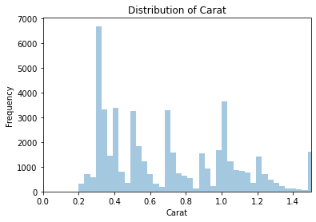

```python
lim = np.arange(0,6,0.05)

sb.distplot(diamonds.carat, kde=False, bins=150)

plt.xlabel('Carat')
plt.ylabel('Frequency')
plt.title('Distribution of Carat')
plt.xlim(0,1.5)
plt.show()
```

there is a large spike around a single decimal value, then a gradual tailing off to the right until the next spike.

##### Now, let's move on to exploring the other three 'C' quality measures: cut, color, and clarity.

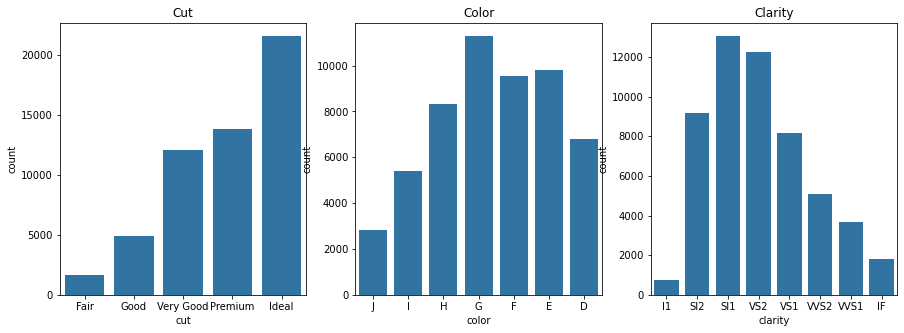

```python
# univariate plots of cut, color, and clarity grades
fig, ax = plt.subplots(nrows=1,ncols=3, figsize = [15,5])

base = sb.color_palette()[0]

sb.countplot(data=diamonds, x='cut', ax=ax[0], color=base)
ax[0].set_title('Cut')

sb.countplot(data=diamonds, x='color', ax=ax[1], color=base)
ax[1].set_title('Color')

sb.countplot(data=diamonds, x='clarity', ax=ax[2], color=base)
ax[2].set_title('Clarity')

plt.show()
```

##### Cut distribution comment:

> the mode cut quality for diamonds in this dataset is the highest grade, Ideal. There is a consistent decrease in number of diamonds of lower cut grades.

##### Color distribution comment:

> The distribution is roughly unimodal, with the most common color grade in this dataset belonging to the central grade represented, G.

##### Clarity distribution comment:

> There is a right-skew in the clarity grades represented in the dataset, with most of the diamonds collected having slight or very slight inclusions (SI2, SI1, VS2, VS1). There are very few diamonds with visible inclusions (I1).

##### I'll now look at the other features in the data to see if any of them hold interesting properties.

> let's start with the major dimensions of the diamonds, with x, y, and z.

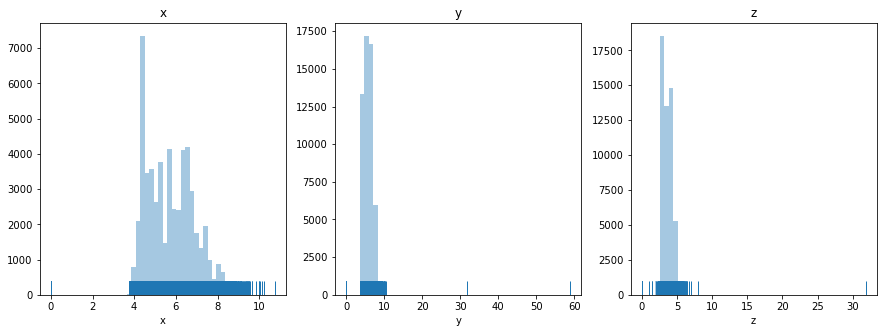

```python
fig, ax = plt.subplots(nrows=1,ncols=3, figsize = [15,5])

base = sb.color_palette()[0]

sb.distplot(diamonds['x'], kde=False, ax=ax[0], rug=True, color=base)
ax[0].set_title('x')

sb.distplot(diamonds['y'], ax=ax[1], kde=False, rug=True, color=base)
ax[1].set_title('y')

sb.distplot(diamonds['z'], ax=ax[2], kde=False, rug=True, color=base)
ax[2].set_title('z')

plt.show()
```

On the y and z plots, most of the data is set to the far left of their axes, suggesting some strong outliers on the right. The left limits of all three plots also suggest that there are some points that take unusually small values.

```python
## Remove Outliers
diamonds['y'] = diamonds['y'][diamonds['y'].between(diamonds['y'].quantile(.15), diamonds['y'].quantile(.85))] # without outliers
diamonds['z'] = diamonds['z'][diamonds['z'].between(diamonds['z'].quantile(.15), diamonds['z'].quantile(.85))] # without outliers
```

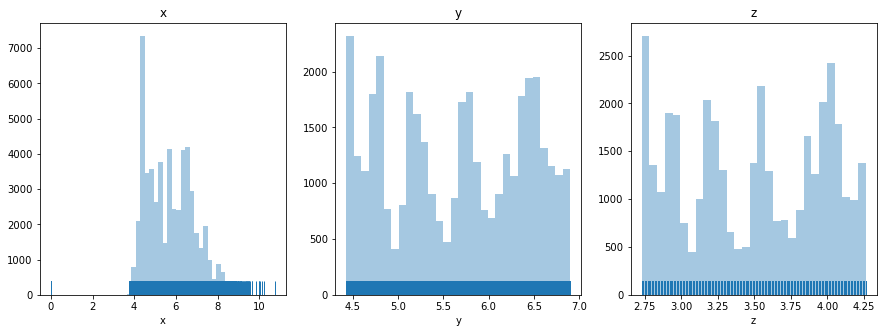

```python
fig, ax = plt.subplots(nrows=1,ncols=3, figsize = [15,5])

base = sb.color_palette()[0]

sb.distplot(diamonds['x'], kde=False, ax=ax[0], rug=True, color=base)
ax[0].set_title('x')


sb.distplot(diamonds['y'], ax=ax[1], kde=False, rug=True, color=base)
ax[1].set_title('y')

sb.distplot(diamonds['z'], ax=ax[2], kde=False, rug=True, color=base)
ax[2].set_title('z')

plt.show()
```

##### Now, we'll investigate relationships between pairs of these variables.

> To start, we will construct a plot of the price against carat weight.

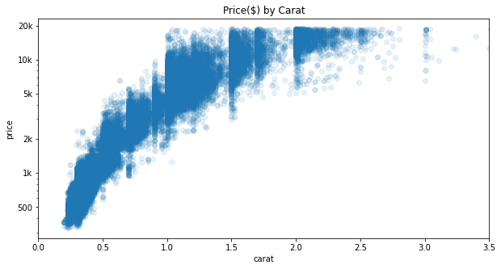

```python
# bivariate plot of price vs. carat
plt.figure(figsize=[10,5])
sb.regplot(data= diamonds, x='carat', y='price',fit_reg=False, scatter_kws={'alpha':0.1})
plt.xlim(0,3.5)
plt.yscale('log')
plt.yticks([500, 1e3, 2e3, 5e3, 1e4, 2e4], [500, '1k', '2k', '5k', '10k', '20k'])
plt.title('Price($) by Carat')
plt.show()
```

the trend between price and carat weight is 'cut off' by the maximum price limit of diamonds available in the dataset. For diamonds above about 1.5 carats, we'd probably expect some diamonds about $20,000 in price, given the trend below 1.5 carats.

##### Now let's take a look at the relationship between price and the three categorical quality features, cut, color, and clarity.

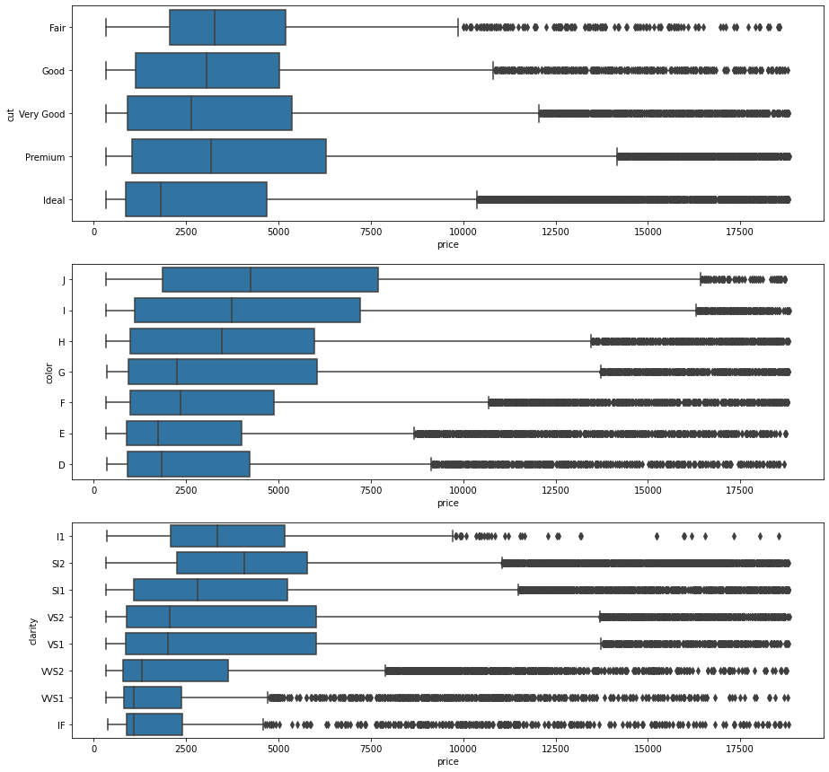

```python
# bivariate plots of price vs. cut, color, clarity
fig, ax = plt.subplots(nrows=3, figsize=[15,15])

sb.boxplot(data=diamonds, x='price', y='cut', ax=ax[0], color=sb.color_palette()[0])

sb.boxplot(data=diamonds, x='price', y='color', ax=ax[1], color=sb.color_palette()[0])

sb.boxplot(data=diamonds, x='price', y='clarity', ax=ax[2], color=sb.color_palette()[0])
plt.show()
```

the median price of diamonds look like it *decrease* with *increasing* gem quality. we expect this to be the other way around.